# Statistical inference with the GSS data

Javier Montaño

22 de junio de 2020

## Setup

### Load packages

```r
library(tidyverse)
```

### Load data

```r
load("C:/Users/Javi3/Documents/JAVIER/R/Duke/gss.RData")
```

## Part 1: Data

the data sample if collected anually by phone surveys so it seens very good, fot the independence of the participants, i belive that each of the participants are choose ramdonly so is nice.

## Part 2: Research question

Are acceptance of the homosexuality along the time depends of the sex and the education degrees of a person?

we must concern of this issuu becouse as a members of a plural and multydiverse society, it becomes necesary to know the factors thats makes us more respefull to the diferents of the members of our comunities

## Part 3: Exploratory data analysis

### Data

```r
data1 <- gss[!is.na(gss$homosex),] %>% select(year, sex, degree, homosex) %>% group_by(year, sex, degree, homosex) %>% summarise(people = n(), .groups = "drop")
data2 <- gss[!is.na(gss$homosex),] %>% select(year, sex, degree) %>% group_by(year, sex, degree) %>% summarise(people1 = n(), .groups = "drop")
data <- merge(data1, data2)
data <- data %>% mutate(proportion = people/people1)
data <- data[,c(1, 2, 3, 4, 7)] %>% filter(homosex %in% c("Always Wrong", "Not Wrong At All"))
```

### Plot

the plot shows us the change of the proportion of people who think that the homosexual relationships are **Always Wrong* in the upper and the proportion of people who think that homosexual relationship are *No Wrong At All* each line has a type represent the sex of the people and the color of the linerepresent the higest education degree.

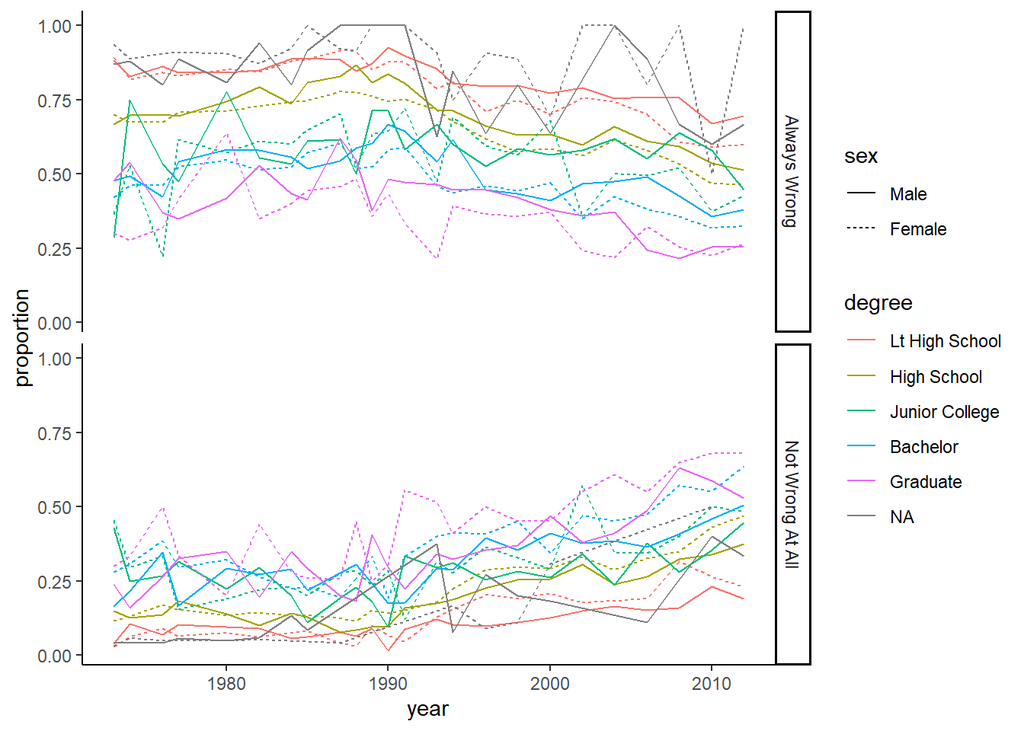

```r
ggplot(data) + geom_line(mapping = aes(x = year, y = proportion, color = degree, linetype = sex)) + facet_grid(rows = vars(homosex)) + theme_classic()
```

in general along the time the proportion of people who think is *Wrong* is smaller and the proportion of people who think taht is *No Wrong* is bigger, futhermore the proportion is increment with more educatinal level of the people and the women has a lager proportion than men.

### Summary

```r
data %>% group_by(sex, degree, homosex) %>% summarise(meanp = mean(proportion), medianp = median(proportion),desviationp = sd(proportion))
```

```
## # A tibble: 24 x 6
## # Groups:   sex, degree [12]
##    sex   degree         homosex          meanp medianp desviationp
##    <fct> <fct>          <fct>            <dbl>   <dbl>       <dbl>
##  1 Male  Lt High School Always Wrong     0.824  0.842       0.0649
##  2 Male  Lt High School Not Wrong At All 0.106  0.0995      0.0493
##  3 Male  High School    Always Wrong     0.702  0.699       0.0968
##  4 Male  High School    Not Wrong At All 0.190  0.166       0.0867
##  5 Male  Junior College Always Wrong     0.584  0.582       0.104
##  6 Male  Junior College Not Wrong At All 0.273  0.273       0.0862
##  7 Male  Bachelor       Always Wrong     0.511  0.505       0.0843
##  8 Male  Bachelor       Not Wrong At All 0.307  0.292       0.0949
##  9 Male  Graduate       Always Wrong     0.412  0.420       0.102
## 10 Male  Graduate       Not Wrong At All 0.348  0.345       0.126
## # ... with 14 more rows
```

shows the same behavior seen previously.

## Part 4: Inference

```r
mod <- lm(proportion ~ homosex + degree + sex + year, data)
anova(mod)
```

```
## Analysis of Variance Table
##
## Response: proportion
##            Df  Sum Sq Mean Sq  F value  Pr(>F)
## homosex     1 12.0259 12.0259 468.6854 < 2e-16 ***
## degree      4  0.3172  0.0793   3.0902 0.01574 *
## sex         1  0.0009  0.0009   0.0336 0.85464
## year        1  0.0804  0.0804   3.1326 0.07739 .
## Residuals 472 12.1109  0.0257
## ---
## Signif. codes:  0 '***' 0.001 '**' 0.01 '*' 0.05 '.' 0.1 ' ' 1
```

the anova shows us differecies in the proporciton of people who thinks either homosesuality is Wrong or Not, equally shows us significative diferencies within the people with some educational level of degree and no diference for the sex or the year.